# R Notebook

## plotting all the varaibles

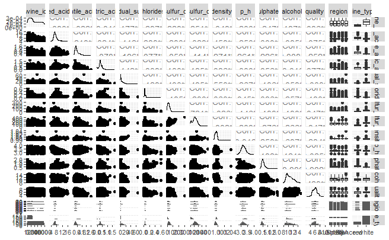

```r
wines %>%
 ggpairs(progress = FALSE)
```

Lets first have a look at the distribution of the quality variable

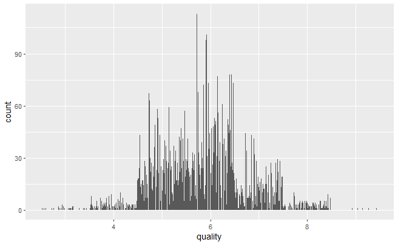

The distribution suggests that the majority of wines have been scored between 4.5 and 7.5 withe very few being at both ends of the scale from 0-10.

Let’s have a closer look at region and wine type to see whether it is worth keeping them in the model in relation to quality.

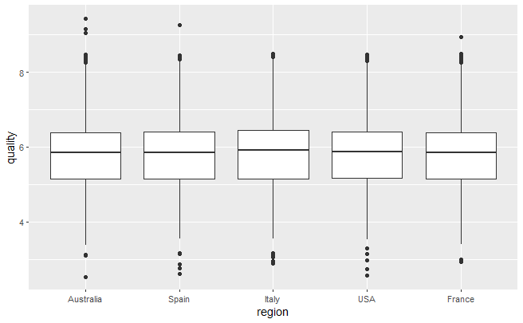

```r
wines %>%
  ggplot(aes(x = region, y = quality))+
  geom_boxplot()
```

It looks like the quality of wines produced by different countries is comparable, so I will not use region in further analysis.

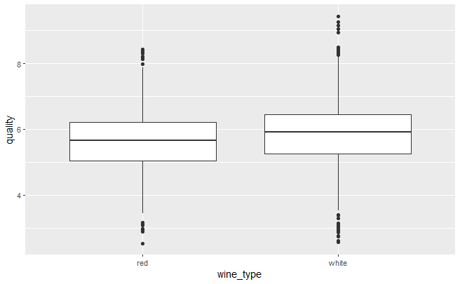

The type of wine and quality seem to be comparable. The majority of ratings for both types of wine fall between 5 and 6.5. I will also not use this predictor in future analysis.

```r
wines <- wines %>%
  select(-c(wine_id, region, wine_type))
```

Let’s find out if there are any aliases in the data

```r
alias(quality ~ ., wines)
```

```
Model :
quality ~ fixed_acidity + volatile_acidity + citric_acid + residual_sugar +
    chlorides + free_sulfur_dioxide + total_sulfur_dioxide +
    density + p_h + sulphates + alcohol
```

```r
# no aliases in the data set, so we can progress with teh current data set
```

lets find out correlations between variables

[figure not shown]

```r
wines %>%
  ggcorr(label = TRUE)
ggsave("correlation_wines.png")
```

We can notice that there is a moderate positive correlation between quality and alcohol, and negative weak correlation between quality and volatile_acidity, and quality and density. There is also weak neagative correlation between quality and chlorides. There is a very weak positive correlation between quality and citric acid and very weak negative correlation between quality and fixed acidity. There seem to be no correlation between quality and sulphates, ph, total sulfur dioxide, free sulfur dioxide and residual sugar.

```r
summary(mod1)
```

```
Call:
lm(formula = quality ~ alcohol, data = wines)

Residuals:
    Min      1Q  Median      3Q     Max
-3.4852 -0.5552 -0.0293  0.5507  3.3362

Coefficients:
            Estimate Std. Error t value Pr(>|t|)
(Intercept) 2.362872   0.091794   25.74   <2e-16 ***
alcohol     0.331822   0.008693   38.17   <2e-16 ***
---
Signif. codes:  0 ‘***’ 0.001 ‘**’ 0.01 ‘*’ 0.05 ‘.’ 0.1 ‘ ’ 1

Residual standard error: 0.8357 on 6495 degrees of freedom
Multiple R-squared:  0.1832,    Adjusted R-squared:  0.1831
F-statistic:  1457 on 1 and 6495 DF,  p-value: < 2.2e-16
```

Around 18% of the variance in quality can be explained by alcohol. On average for every one unit increase in alcohol the quality should increase by 0.33 units. The coefficient is statistically significant.

let’s check if it is better to add density or volatile_acidity to the model

```r
mod2a <- lm(quality ~ alcohol + density, data = wines)

summary(mod2a)
```

```
Call:
lm(formula = quality ~ alcohol + density, data = wines)

Residuals:
    Min      1Q  Median      3Q     Max
-3.4854 -0.5553 -0.0293  0.5508  3.3366

Coefficients:
            Estimate Std. Error t value Pr(>|t|)
(Intercept)  2.54884    4.81891   0.529    0.597
alcohol      0.33150    0.01196  27.718   <2e-16 ***
density     -0.18361    4.75709  -0.039    0.969
---
Signif. codes:  0 ‘***’ 0.001 ‘**’ 0.01 ‘*’ 0.05 ‘.’ 0.1 ‘ ’ 1

Residual standard error: 0.8357 on 6494 degrees of freedom
Multiple R-squared:  0.1832,    Adjusted R-squared:  0.183
F-statistic: 728.4 on 2 and 6494 DF,  p-value: < 2.2e-16
```

The r-squared value has not changed anything and the coefficient for density is not statistically significant, which suggests that density should not be added to the model at this stage.

```r
# adding volatile_acidity to the model as a second predictor
mod2b <- lm(quality ~ alcohol + volatile_acidity, data = wines)

summary(mod2b)
```

```
Call:
lm(formula = quality ~ alcohol + volatile_acidity, data = wines)

Residuals:
    Min      1Q  Median      3Q     Max
-3.6091 -0.5231 -0.0097  0.5187  3.2431

Coefficients:
                  Estimate Std. Error t value Pr(>|t|)
(Intercept)       2.885721   0.091803   31.43   <2e-16 ***
alcohol           0.324930   0.008398   38.69   <2e-16 ***
volatile_acidity -1.326428   0.060840  -21.80   <2e-16 ***
---
Signif. codes:  0 ‘***’ 0.001 ‘**’ 0.01 ‘*’ 0.05 ‘.’ 0.1 ‘ ’ 1

Residual standard error: 0.8067 on 6494 degrees of freedom
Multiple R-squared:  0.2389,    Adjusted R-squared:  0.2387
F-statistic:  1019 on 2 and 6494 DF,  p-value: < 2.2e-16
```

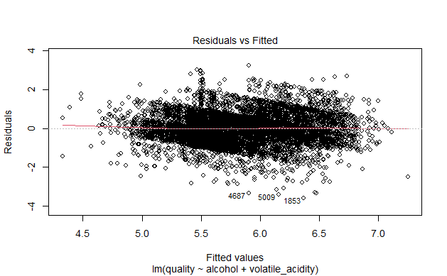

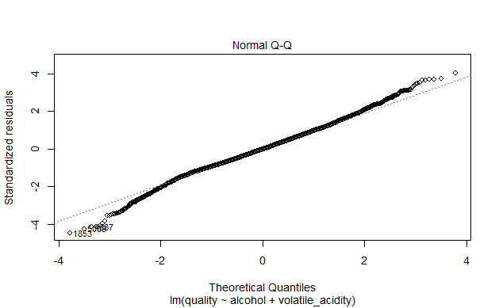

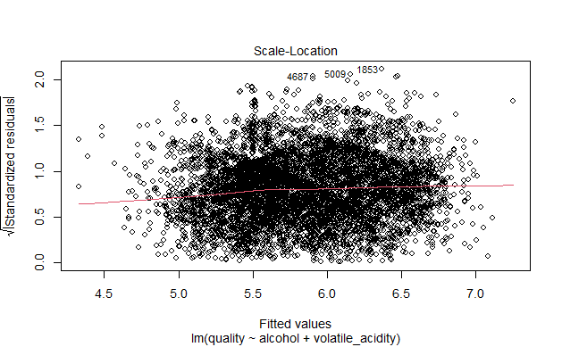

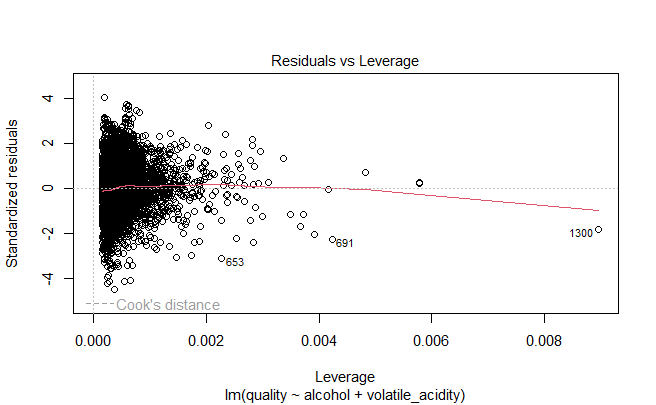

```r
plot(mod2b)
```

Let’s check if adding density and chloride as third predictors will improve the model

```r
summary(mod3a)
```

```
Call:
lm(formula = quality ~ alcohol + volatile_acidity + chlorides,
    data = wines)

Residuals:
    Min      1Q  Median      3Q     Max
-3.6078 -0.5237 -0.0098  0.5184  3.2451

Coefficients:
                  Estimate Std. Error t value Pr(>|t|)
(Intercept)       2.872877   0.097681  29.411   <2e-16 ***
alcohol           0.325809   0.008703  37.436   <2e-16 ***
volatile_acidity -1.336067   0.065792 -20.307   <2e-16 ***
chlorides         0.123093   0.319694   0.385      0.7
---
Signif. codes:  0 ‘***’ 0.001 ‘**’ 0.01 ‘*’ 0.05 ‘.’ 0.1 ‘ ’ 1

Residual standard error: 0.8068 on 6493 degrees of freedom
Multiple R-squared:  0.2389,    Adjusted R-squared:  0.2386
F-statistic: 679.5 on 3 and 6493 DF,  p-value: < 2.2e-16
```

[figure not shown]

[figure not shown]

[figure not shown]

[figure not shown]

[figure not shown]

[figure not shown]

[figure not shown]

[figure not shown]

```r
model_2b <- train(quality ~ alcohol + volatile_acidity, data = wines,
               trControl = cv_10_fold, # use options defined above
               method = 'lm')
# calculate an average error
mean(model_2b$resample$RMSE)
```

```
[1] 0.8065372
```

```r
# calculate an average r-square value
mean(model_2b$resample$Rsquared)
```

```
[1] 0.2395072
```